# PacDev Case

Hasitha Josyula

11-06-2022

## Q1

```r
library(tidyverse)
d <- read_csv("pacdev_data.csv")
```

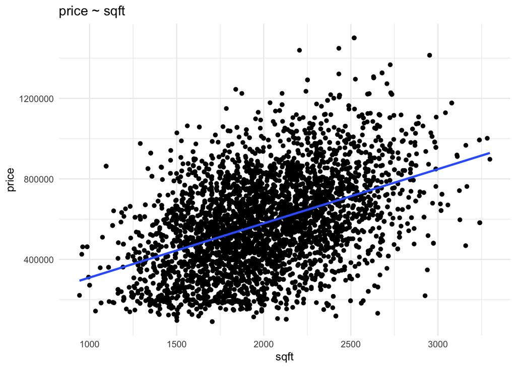

```r
#1.Plot price against sqft with a summary linear regression line.

ggplot(d, aes(sqft, price)) +geom_point() +theme_minimal() +stat_smooth(method="lm", se = F) +labs(title = "price ~ sqft")
```

```r
#2.Determine the equation of the summary line in the plot (by fitting the corresponding regression model) and interpret the coefficients for the intercept and sqft in the equation.
linear_model <- lm(price ~ sqft, data = d)
linear_model %>% summary
```

```
##
## Call:
## lm(formula = price ~ sqft, data = d)
##
## Residuals:
##     Min      1Q  Median      3Q     Max
## -622948 -151283   -1650  138951  804553
##
## Coefficients:
##              Estimate Std. Error t value Pr(>|t|)
## (Intercept) 40623.019  15862.454   2.561   0.0105 *
## sqft          269.345      7.742  34.791   <2e-16 ***
## ---
## Signif. codes:  0 '***' 0.001 '**' 0.01 '*' 0.05 '.' 0.1 ' ' 1
##
## Residual standard error: 210300 on 4989 degrees of freedom
## Multiple R-squared:  0.1953, Adjusted R-squared:  0.1951
## F-statistic:  1210 on 1 and 4989 DF,  p-value: < 2.2e-16
```

> From the above plot & analysis, the equation is price = (40623.019 + 269.345*sqft). We can say observe that there is a positive correlation between price and sqft i.e., as the sqft increases the price also increases.

## Q2

```r
#1.Fit a multiple regression model of price with all the available predictors entered additively (+). However, create a centered version of sqft (by subtracting the mean from each observation) and use this as a predictor rather than the original variable. (There should be 8 coefficients in this model.)

centeredsqft <- d$sqft - mean(d$sqft)

regressionmodel_nonint <- lm(price ~ centeredsqft + city + pool + garage + bed + bath, data=d)
regressionmodel_nonint %>% summary
```

```
##
## Call:
## lm(formula = price ~ centeredsqft + city + pool + garage + bed +
##     bath, data = d)
##
## Residuals:
##     Min      1Q  Median      3Q     Max
## -539286 -137407   -3532  124838  852187
##
## Coefficients:
##                    Estimate Std. Error t value Pr(>|t|)
## (Intercept)      528103.213   9291.990  56.834   <2e-16 ***
## centeredsqft        271.561      7.515  36.138   <2e-16 ***
## citySanta Monica 190239.704   6757.751  28.151   <2e-16 ***
## cityWestwood      88020.719   6794.984  12.954   <2e-16 ***
## poolyes           10124.630   6760.090   1.498   0.1343
## garageyes        -14195.911   6120.799  -2.319   0.0204 *
## bed                  41.553   8420.185   0.005   0.9961
## bath              -3092.909   9439.900  -0.328   0.7432
## ---
## Signif. codes:  0 '***' 0.001 '**' 0.01 '*' 0.05 '.' 0.1 ' ' 1
##
## Residual standard error: 195000 on 4983 degrees of freedom
## Multiple R-squared:  0.3085, Adjusted R-squared:  0.3075
## F-statistic: 317.6 on 7 and 4983 DF,  p-value: < 2.2e-16
```

> #2.Interpret the 4 coefficients for the intercept, centered sqft, and city. Remember that Long Beach is the (missing) reference city in the model, assuming that factor levels have been assigned alphabetically. price = 528103.213+271.561 * centeredsqft +190239.704 * citySantaMonica +88020.719 * cityWestwood +10124.630 * poolyes -14195.911 * garageyes + 41.553 * bed -3092.909 * bath

> From the above analysis, the intercept is positive which is 528103.213 and slope for centeredsqft is 271.561. The slopes for city Santa Monica and cityWestwood are 190239.704 & 88020.719 respectively. Since the slopes are postive, we can say that the price increases with one unit change in variables. Among all the cities, SantaMonica has the highest slope value.

## Q3

```r
#1.To the above model add an interaction between centered sqft and city. This means that you combine these terms multiplicatively (*) rather than additively (+).
interaction_model <- lm(price ~ centeredsqft * city + pool + garage + bed + bath, data=d)
interaction_model %>% summary
```

```
##
## Call:
## lm(formula = price ~ centeredsqft * city + pool + garage + bed +
##     bath, data = d)
##
## Residuals:
##     Min      1Q  Median      3Q     Max
## -536726 -138828   -2505  124312  868332
##
## Coefficients:
##                                Estimate Std. Error t value Pr(>|t|)
## (Intercept)                   527445.45    9270.43  56.895  < 2e-16 ***
## centeredsqft                     240.63      10.14  23.726  < 2e-16 ***
## citySanta Monica              189904.29    6741.32  28.170  < 2e-16 ***
## cityWestwood                   88037.11    6778.98  12.987  < 2e-16 ***
## poolyes                        10817.17    6744.71   1.604   0.1088
## garageyes                     -14205.98    6108.49  -2.326   0.0201 *
## bed                              235.26    8403.39   0.028   0.9777
## bath                           -3099.26    9419.64  -0.329   0.7422
## centeredsqft:citySanta Monica     90.09      17.49   5.152 2.68e-07 ***
## centeredsqft:cityWestwood         37.95      18.05   2.103   0.0356 *
## ---
## Signif. codes:  0 '***' 0.001 '**' 0.01 '*' 0.05 '.' 0.1 ' ' 1
##
## Residual standard error: 194500 on 4981 degrees of freedom
## Multiple R-squared:  0.3122, Adjusted R-squared:  0.311
## F-statistic: 251.2 on 9 and 4981 DF,  p-value: < 2.2e-16
```

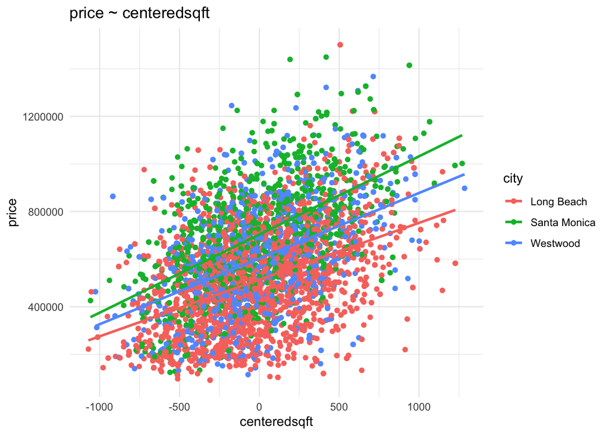

```r
#2.Create a visualization of this interaction model, making sure to use centered sqft in the plot.
ggplot(d, aes(centeredsqft, price, col=city)) +geom_point() +theme_minimal() +stat_smooth(method="lm", se = F) +labs(title = "price ~ centeredsqft")
```

>#3.Interpret 6 coefficients from this model: the intercept, the main effects for centered sqft and city, and the interaction effects. >From the plot and analysis, we can say observe that the intercept for this interaction model is positive i.e., 527445.45. The Main effects: * Slope for centeredsqft is 240.63. * Slope for cities citySanta Monica & cityWestwood are 189904.29 and 88037.11 respectively. For both the cities, the slopes are positive which indicates that the price will increase with one unit change in variables. Interaction effects: * The centeredsqft for cities citySanta Monica & cityWestwood are 90.09 & 37.95. We can see that they are positive, indicating there is a price increase with interactions. Also, among all the cities, the city Santa Monica has the interaction effect.